# Homework7

Jonathan Pilling

## Problem 1

Problem 19.4 from the book

**Part(a)**

**Answer:**

The function $g(x) = 1/x$ is convex, so according to Jensen’s inequality: $E[T] = E[\frac{1}{\bar {X}_n}] > \frac{1}{E[\bar{X}_n]}$

Note that $E[\bar{X}_n] = E[X_1] = \frac{1}{p}$ Now we can plug in this value for the right hand side of the inequality, so we get $E[T] > \frac{1}{1/p} = E[T] > p$ This tells us that T is a biased estimator for p because it’s not equivalent, and we know because $E[T] > p$ we have positive bias.

**Part(b)**

**Answer:**

For each i label $X_i < 3$ as a success, then the total number $Y$ of all successes has a $Bin(n, \theta)$ distribution where $\theta = p + (1-p)p+(1-p)^2p$. This represents the probability that a woman becomes pregnant within three or fewer cycles. This implies that $E[Y] = n\theta$ and therefore $E[S] = E[Y/n] = E[Y]/n = \frac{n\theta}{n} = \theta$

Because these are equal, this means that S is an unbiased estimator.

## Problem 2

**Part(a)**

Give an unbiased statistic that you would use to estimate n.

**Answer:**

$$\bar{X} = \frac{X_1 + X_2 + ... + X_{10}}{10}\\
\text{Using linearity of expectation}\\
E[\bar{X}] = 1/10(E[X_1] + E[X_2] + ... + E[X_{10}])\\
E[X_i] = n * P(H) = n/2\\
E[\bar{X}] = \frac{1}{10} * 10 * \frac{n}{2} = \frac{n}{2}\\
\text{Solving for n}\\
n = E[2\bar{X}]\\$$
Because the probability of flipping a coin is 1/2, the number of heads we get multiplied by 2 should be equivalent to n. This gives us a bias of zero, or an unbiased estimate.

**Part(b),(c),(d)**

Simulate this experiment 10,000 times with n = 25.

**Answer:**

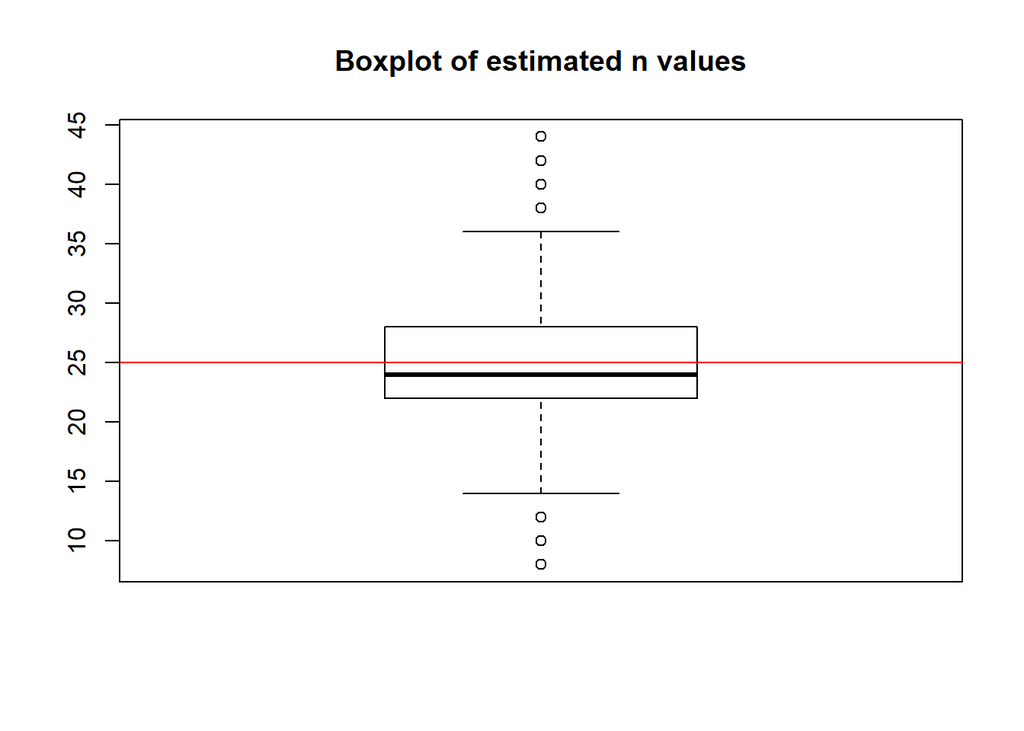

```r
#We'll use 1 for heads and 0 for tails
#Flip coin function to flip a coin for certain n value
FlipCoin = function(n) sample(1:0, n, rep = T)

#We will use this to simulate our n value
n = 25
nHat = c()
ExpectedValue = 2 * n/2
#This represents the expirement, 25 coin flips passed in for n, we do n amount of coin flips 10x
for (i in 1:10000) {
  for (j in 1:10) {
  C = FlipCoin(25)
  }
  #Using our equation from part a
  nHat[i] <-sum(C==1) * 2
}

#Plotting a boxplot of nHat values
boxplot(nHat, main="Boxplot of estimated n values")
abline(h = 25, col = "red")
```

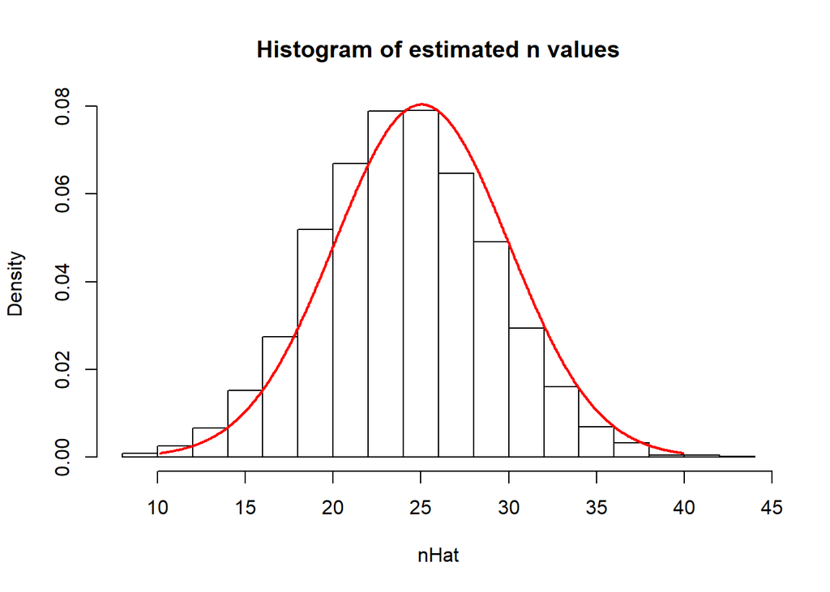

```r
#Plotting a histogram of nHat values
hist(nHat, freq = FALSE, main = "Histogram of estimated n values")

#values for mu and sigma hat
mu.hat = mean(nHat)
sigma.hat = var(nHat)

#Plotting of Gaussian pdf
s = seq(mu.hat - 3*sd(nHat), mu.hat + 3*sd(nHat), 0.01*sd(nHat))
lines(s, dnorm(s, mean(nHat), sd(nHat)), col = 'red', lwd = 2)
```

Note that for the boxplot, the n values are roughly centered around the red line that represents the true value of n.

## Problem 3

Exercise 23.3. Caluculate the confidence interval in R using the formula in the notes. You should use qnorm function.

**Answer:**

```r
## Information given in problem
xBar = 93.5 #Average weight of a bag of cement
sigma = sqrt(0.75)  ## We square sample standard deviation
n = 10 #Number of cement bags

lower = xBar - qnorm(0.975) * sigma / sqrt(n)
upper = xBar + qnorm(0.975) * sigma / sqrt(n)
```

The 95% confidence interval is (92.9632418, 94.0367582).

## Problem 4

Exercise 23.10

**(a)**

What is the mean of the unknown dataset?

**Answer:** From the confidence interval obtained, we know the sample mean is in the middle. $(1.6 + 7.8)/2 = 4.7$

**(b)**

You prefer to have a 99% confidence interval for $\mu$. Construct it.

**Answer:** We have the mean and we have the number of observations so we just have to find our sample standard deviation.
$$\text{Finding Sample Variance}\\
\text{Using } L_n = \bar{X}_n - t_{\alpha/2} * \frac{S_n}{\sqrt{n}}\\
1.6 = 4.7 - t_{\alpha/2} * S_n/\sqrt{16}\\$$
We need to find $t_{\alpha/2}$ We can do this in r fairly easily.

```r
#Since confidence intervals are for 95% and we have 16 observations
tValue = qt(1 - 0.025, df = 15)
print(tValue)
```

```
## [1] 2.13145
```

tValue is equal to $2.131$ Now we can finish solving our equation.

$$1.6 = 4.7 - 2.131* S_n/4\\
-3.1 = -2.131 * S_n/4\\
1.45 = S_n/4\\
S_n = 5.819$$
Now we will calculate with R Code

```r
xBar = 4.7 #Mean that we calculated
s = 5.819 #Sample Variance we calculated
n = 16 #This interval is based on 16 observations.

#These will produce 99% Confidence Intervals
lower = xBar - qt(0.995, df = n - 1) * s / sqrt(n)
upper = xBar + qt(0.995, df = n - 1) * s / sqrt(n)
```

The 99% confidence interval for the mean is (0.4132694, 8.9867306).

## Problem 5

In this problem you are going to analyze the built-in R data set iris.

First we’ll extract virginica species and save it

```r
x = iris$Sepal.Width[iris$Species == "virginica"]
```

**(a)**

Using a Gaussian approx., what is the 95% confidence interval for the mean of x?

**Answer:**

```r
## Information given in problem
xBar = mean(x)
sigma = sqrt(var(x)) ## standard deviation = sqrt(variance)
n = length(x)

lower = xBar - qnorm(0.975) * sigma / sqrt(n)
upper = xBar + qnorm(0.975) * sigma / sqrt(n)
```

The 95% confidence interval is (2.8846101, 3.0633899).

**(b)**

Using a student t distribution, what is the 95% confidence interval for the mean of x?

**Answer:** We need to calculate the sample variance

```r
xBar = mean(x)
s = sd(x)
n = length(x)

lower = xBar - qt(0.975, df = n - 1) * s / sqrt(n)
upper = xBar + qt(0.975, df = n - 1) * s / sqrt(n)
```

The 95% confidence interval for the mean is (2.8823475, 3.0656525).

**(c)**

Now assume that we have only the first 10 measurements.

**Answer:**

Creates a new vector y with the first 10 elements

```r
y = x[1:10]
```

Now we’ll repeat parts a and b for our new vector y

```r
## Information given in problem
xBar = mean(y)
sigma = sd(y) ## standard deviation = sqrt(variance)
n = length(y)

lower = xBar - qnorm(0.975) * sigma / sqrt(n)
upper = xBar + qnorm(0.975) * sigma / sqrt(n)
```

The 95% confidence interval is (2.7309372, 3.1490628).

```r
xBar = mean(y)
s = sd(y)
n = length(y)

lower = xBar - qt(0.975, df = n - 1) * s / sqrt(n)
upper = xBar + qt(0.975, df = n - 1) * s / sqrt(n)
```

The 95% confidence interval for the mean is (2.6987032, 3.1812968).

**(d)**

How did the decrease in sample size affect the results?